# MacOSサポート

2023-05-06

# 1 Mac OS へのサポート

## 1.1 Anaconda Navigatorのインストール方法（MacOS版）

[ここ](https://github.com/oyo-k/book/blob/master/documents/Mac_Anaconda%E3%81%AE%E3%82%A4%E3%83%B3%E3%82%B9%E3%83%88%E3%83%BC%E3%83%AB%E6%96%B9%E6%B3%95.pdf)を参考にAnaconda Navigatorをインストールしましょう。

以上の操作でインストール完了です。書籍に戻り作業を再開しましょう。

## 1.2 作業フォルダの準備（本書の2.2.1節Mac対応）

Jupyter Notebook を起動する前に、本書で作成するPythonのプログラムを保存するために、ホームの直下に「pysrc」というフォルダを作成します。次の手順のとおりに作業しましょう。

- 手順1 Finderのアイコンをクリックし、Finderを開きます。
- 手順2 Finderの(1)の移動にマウスカーソルを合わせ、(2)のホームをクリックします。

[figure not shown]

Finder上にはguestなどのホームと呼ばれるファイルの保存場所があります。読者の画面には、guestではなく、読者のMacのユーザー名が記載されています。- ホームのフォルダやファイルに重ならないように、guestフォルダの空欄部分を右クリックし、(3)の新規フォルダをクリックします。

[figure not shown]

手順4: 名称未設定フォルダを右クリックし、名前を変更をクリックします。

[figure not shown]

- 手順5: 半角英数でフォルダ名「pysrc」を入力して、pysrcフォルダを作成します。

次のJupyter Notebookの起動へ進みます。

## 1.3 Jupyter Notebookの起動（本書の2.2.2節Mac対応）

Jupyter Notebook を起動するために、次のように作業しましょう。- 手順1 Finderのアイコンをクリックし、Finderを開きます。

- 手順2 移動にカーソルを合わせて、アプリケーションをクリックします。

[figure not shown]

- 手順3 「Anaconda Navigator」をクリックし、Anaconda Navigatorを起動します。

[figure not shown]

- 手順4 「Environments」をクリックします。base(root)の「右三角のマーク」をクリックしてから、「Open Terminal」をクリックし、ターミナルを開きます。

[figure not shown]

- 手順5 半角入力モードになっていることを確認します。もし全角入力モードになっている場合は、キーボードの左下の英数キーを押して半角入力モードにします。次に現在開いているターミナルに「jupyter notebook pysrc」を入力し、エンターキーを押します。

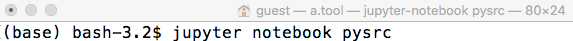

この手1から5はプログラムを作成する環境であるJupyter Notebook を立ち上げるための操作です。Anaconda Navigator を起動してプログラミングを始めるときは、毎回行います。「jupyter notebook pysrc」はpysrc フォルダ上でプログラミングを便利に進めるためのコマンドとみなしましょう。詳しくは第8章で解説します。

本書の2.2.3章に戻りましょう。